# Dasen lab, Pbx-mutant RNAseq, controls

Lisa J. Cohen

# Introduction

This is an RNASeq differential expression analysis from paired-end 50 data from Illumina HiSeq 2500 high-output sequencing runs, Combo_HSQ_24 and Combo_HSQ_10 that took place at the NYU Genome Technology Center on November 18, 2014 and August 27, 2014, respectively.

The BaseSpace link with run quality information is here: https://basespace.illumina.com/s/nblJAnaXNEuX

# Table of Contents:

1. Data Analysis Procedure
2. PCA
3. MA plots
4. Heatmap
5. Version Info
6. References

# 1. Data analysis procedure

For CPM data, the alignment program, Bowtie (version 1.0.0) was used with reads mapped to the Ensemble NCBIM37/mm9 (iGenome version) with two mismatches allowed. The uniquely-mapped reads were subjected to subsequent necessary processing, including removal of PCR duplicates, before transcripts were counted with htseq-count. Counts files were imported into the R statistical programming environment and analyzed with the DESeq2 R/Bioconductor package (Love et al. 2014).

Here, data analysis is presented from the thoarcic-level and brachial-level controls.

Filenames containing raw transcript counts from htseq-count are as follows:

```
## [1] "BR-A-Control_counts.txt" "BR-B-Control_counts.txt"
## [3] "BR-C-Control_counts.txt" "TH-A-Control_counts.txt"
## [5] "TH-B-Control_counts.txt" "TH-C-Control_counts.txt"
```

# 2. PCA

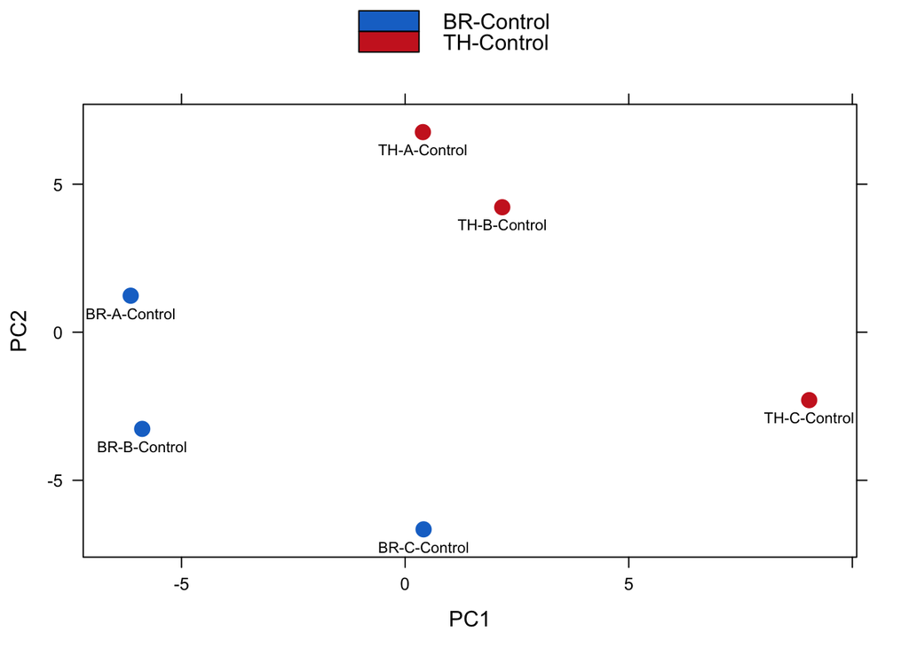

# 3. MA plots

The size of the table with all transcripts is:

```
## [1] 13624    15
```

The size of the table with only significant transcripts, padj<0.05 is:

```
## [1] 280  15
```

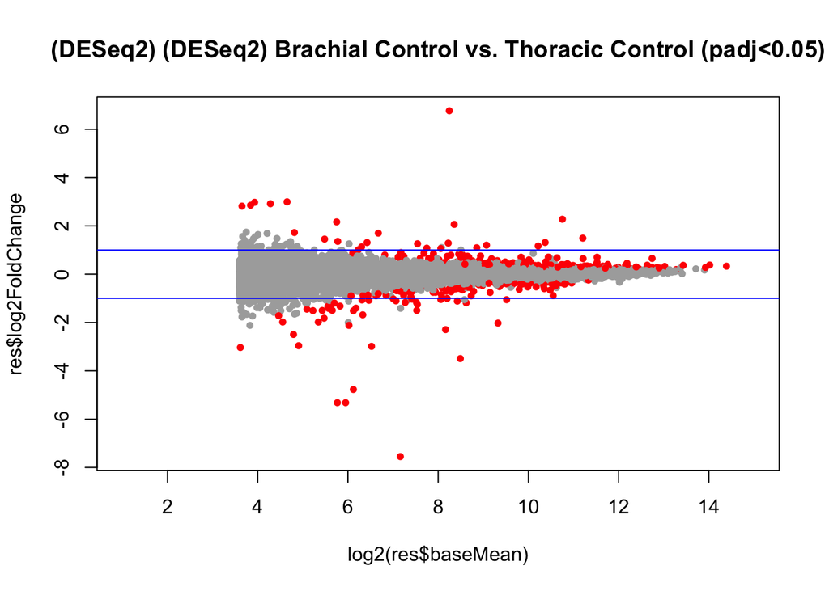

# 4. Heatmap

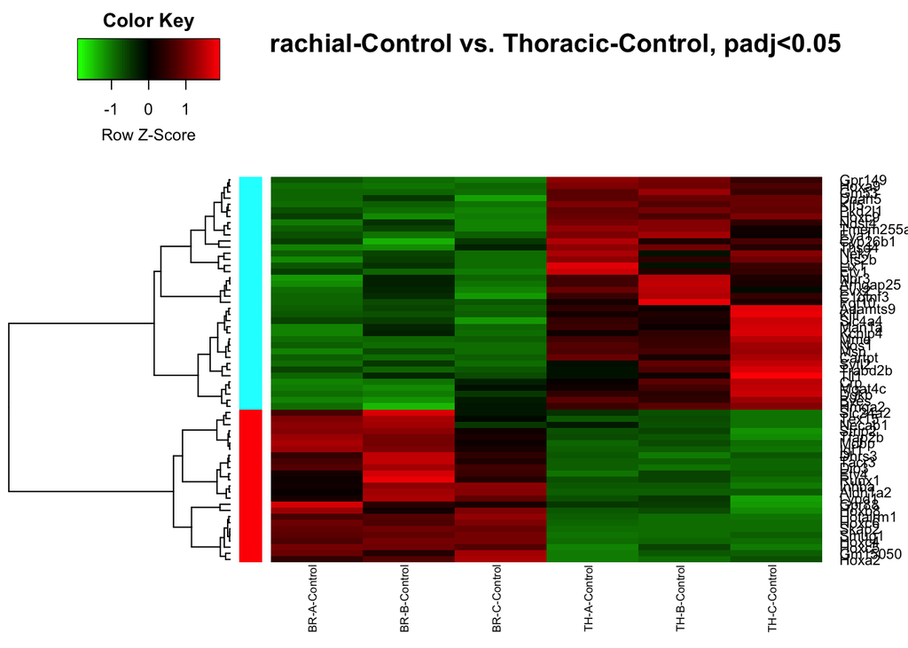

# 5. Version Info

### Sequencing and original bioinformatics analysis by:

NYU Langone Medical Center  
Bioinformatics Core, Genome Technology Center, OCS  
Email: Genomics@nyumc.org  
Phone: 646-501-2834  
http://ocs.med.nyu.edu/bioinformatics-core  
http://ocs.med.nyu.edu/genome-technology-center

# 6. References

M. I. Love, W. Huber, S. Anders: Moderated estimation of fold change and dispersion for RNA-seq data with DESeq2. Genome Biology 2014, 15:550. http://dx.doi.org/10.1186/s13059-014-0550-8

R-Bioconductor: http://www.bioconductor.org/

DESeq2: http://www.bioconductor.org/packages/release/bioc/vignettes/DESeq2/inst/doc/DESeq2.pdf